# Analysis

```r
library(rpart)
library(tree)
library(MASS)
library(rpart.plot)
library(tidyverse)
library(dplyr)

citydata <- read.csv("col_citydata.csv", header = TRUE)

#creating a new data frame where we have only one row per city instead of multiple city rows
rows_to_cols <- citydata %>% spread(metrics, price)

#renaming the columns to shorter names
colnames(rows_to_cols) <- c("city", "apt_in_center", "apt_out_center", "salary", "basics", "internet", "meal_for_2", "inexpensive_meal")



full <- read.csv(file = "full_col_data.csv", header = TRUE)

#extracting only the three additional metrics I want to study from the full data frame
subset <- full %>% filter(metrics == "McMeal at McDonalds (or Equivalent Combo Meal)" | metrics == "Gasoline (1 gallon)" | metrics == "International Primary School, Yearly for 1 Child")


#transforming subset to data frame with one row per city
subset2 <- subset %>% spread(metrics, price)
colnames(subset2) <- c("city", "gas", "primary_school", "mcmeal")

#combining the two new data frames I just created.
combined <- left_join(rows_to_cols, subset2, by = "city")
```

We will now try to predict the average monthly net salary using multiple linear regression, based on the price of an apartment in the center, the price of an apartment outside of the center, and the tuition for 1 child at an international primary school, because there seems to be a linear relationship between the salary and each of these covariates independently (based on the EDA we did in the EDA.Rmd file)

```r
#predicting average salary based the price of an apartment in the center, the price of an apartment outside of the center, and the tuition for 1 child at an international primary school
salary_lm <- lm(salary ~ apt_in_center + apt_out_center + primary_school, data = combined)
summary(salary_lm)
```

```
##
## Call:
## lm(formula = salary ~ apt_in_center + apt_out_center + primary_school,
##     data = combined)
##
## Residuals:
##      Min       1Q   Median       3Q      Max
## -1206.80  -530.91   -32.05   413.46  1640.25
##
## Coefficients:
##                 Estimate Std. Error t value Pr(>|t|)
## (Intercept)    1.745e+03  2.940e+02   5.933 3.92e-07 ***
## apt_in_center  8.440e-01  6.709e-01   1.258    0.215
## apt_out_center 8.249e-01  8.076e-01   1.021    0.313
## primary_school 2.257e-02  1.758e-02   1.284    0.206
## ---
## Signif. codes:  0 '***' 0.001 '**' 0.01 '*' 0.05 '.' 0.1 ' ' 1
##
## Residual standard error: 656.2 on 45 degrees of freedom
##   (1 observation deleted due to missingness)
## Multiple R-squared:  0.6882, Adjusted R-squared:  0.6674
## F-statistic: 33.11 on 3 and 45 DF,  p-value: 1.865e-11
```

For a `$`100 increase in the price of an apartment in the center, the average monthly net salary in a city increases by `$`84.4 on average, keeping the other two covariates constant.

For a `$`100 increase in the price of an apartment outside of the center, the average monthly net salary in a city increases by `$`82.5 on average, keeping the other two covariates constant.

For a `$`1000 increase in the yearly tuition for 1 child at an international primary school, the average monthly net salary in a city increases by `$`22.6 on average, keeping the other two covariates constant.

We will now create a Decision Tree to predict the average monthly net salary based on the price of an apartment in the center, the price of an apartment outside of the center, basic utilities, the price of an inexpensive meal, the price of the internet, the price of a meal for two, the price of 1 gallon of gas, the price of a McMeal, and the 1 year tuition for one child at an international primary school.

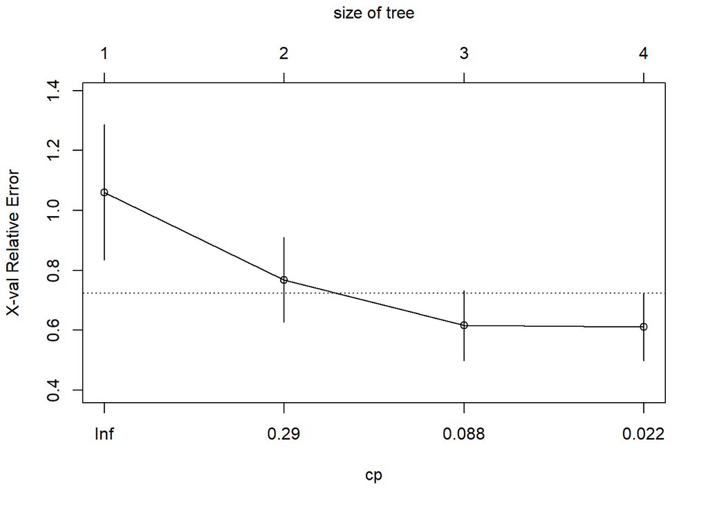

```r
#creating a Decision tree using rpart
fit_rpart <- rpart(salary ~ apt_in_center + apt_out_center + basics + inexpensive_meal + internet + meal_for_2 + gas + mcmeal + primary_school, data = combined)

#looking at the error for different tree sizes
plotcp(fit_rpart)
```

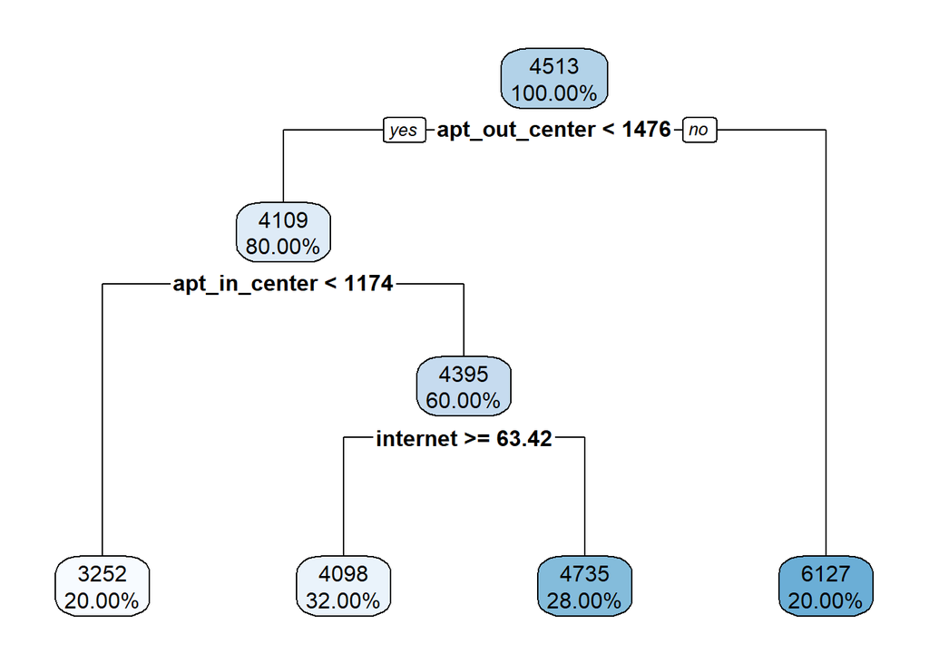

```r
#the lowest error is achieved using a complexity parameter of 0.022
p <- prune(fit_rpart, cp = 0.022)
rpart.plot(p, digits = 4)
```

The **best** Decision Tree tells us that the average monthly net salary is

- `$`6127 in the cities where an apartment outside of the center costs more than `$`1476.
- `$`4109 in the cities where an apartment outside of the center costs less than `$`1476. Among those cities, the average monthly net salary is:
  - `$`3252 in the cities where an apartment in the center costs less than `$`1174
  - `$`4395 in the cities where an apartment in the center costs more than `$`1174. Among those cities, the average monthly net salary is:
    - `$`4735 in the cities where the internet (60 Mbps or More, Unlimited Data, Cable/ADSL) costs less than `$`63.42
    - `$`4098 in the cities where the internet (60 Mbps or More, Unlimited Data, Cable/ADSL) costs at least `$`63.42

Both the linear regression and the decision tree give informative salary predictions, but the decision tree was able to take all of the variables as predictors (even those that do not have a linear relationship with salary) and told us which variables are the most significant predictors in our model. Two of the predictors are the same in the regression model and the decision tree model, but one variable differs. In terms of interpretability, both models are easy to interpret. In our case we would prefer the linear regression model because it gives us specific estimates for our coefficients, which we can use in predicting the average monthly net salary in cities not included in our dataset.

Our second focus is the apartment price in city center since it could best reflect the standard of living. When considering job offer, people would prefer to live near city center for convenience, and the price may deviated a lot in different cities. First, we will get a sense about how city center price differ from each city.

```r
#Regression for apartment price in city center with predictors of apartment price outside city center, basics (in quadratic term), salary, gasoline, inexpensive_meal, primary school, meal for 2
apt_lm <- lm(apt_in_center ~  apt_out_center + basics^2 + salary  + gas+ inexpensive_meal + primary_school + meal_for_2, data = combined)
#summary(apt_lm)
```

```r
#A reduced regression model contains only significant predictors apt_out_center and meal_for_2
apt_lm_r <- lm(apt_in_center ~  apt_out_center + meal_for_2, data = combined)
summary(apt_lm_r)
```

```
##
## Call:
## lm(formula = apt_in_center ~ apt_out_center + meal_for_2, data = combined)
##
## Residuals:
##     Min      1Q  Median      3Q     Max
## -295.84  -80.56  -21.32   96.75  334.04
##
## Coefficients:
##                  Estimate Std. Error t value Pr(>|t|)
## (Intercept)    -311.97804  112.30332  -2.778 0.007835 **
## apt_out_center    1.05686    0.06668  15.850  < 2e-16 ***
## meal_for_2        9.53476    2.42408   3.933 0.000275 ***
## ---
## Signif. codes:  0 '***' 0.001 '**' 0.01 '*' 0.05 '.' 0.1 ' ' 1
##
## Residual standard error: 135.2 on 47 degrees of freedom
## Multiple R-squared:  0.9418, Adjusted R-squared:  0.9394
## F-statistic: 380.5 on 2 and 47 DF,  p-value: < 2.2e-16
```

From above regression, the coefficient for apartment price out of city center and meal for 2 are all positive indicating there is positive relationship between apartment price in city center and the two predictors.

Holding all other variables constant, for 100 dollar increase in the apartment price outside city center, the estimated price for apartment price in city center will increase 106 dollar on average.

Holding all other variables constant, for one dollar increase in the meal for two, the estimated price for apartment price in city center will increase 9.5 dollar on average.

```r
#Using gradient boosting trees algorithm to test the relevance of each predicted variables
#Code Source: https://www.datatechnotes.com/2020/08/regression-example-with-xgboost-in-r.html
#load required library
library(xgboost)
library(caret)
str(combined)
```

```
## 'data.frame':    50 obs. of  11 variables:
##  $ city            : chr  "Albuquerque" "Arlington" "Atlanta" "Austin" ...
##  $ apt_in_center   : num  913 2191 1565 1860 1492 ...
##  $ apt_out_center  : num  753 1678 1133 1198 1007 ...
##  $ salary          : num  3563 6459 5028 5568 4601 ...
##  $ basics          : num  136 124 177 142 143 ...
##  $ internet        : num  74.3 63.6 65.9 63.2 68.6 ...
##  $ meal_for_2      : num  47.5 79 60 60 65 87.5 64 75 55 60 ...
##  $ inexpensive_meal: num  14 15 14 15 15 20 13 16 15 15 ...
##  $ gas             : num  2.46 2.46 2.69 2.57 2.52 2.61 2.44 3.21 2.68 2.65 ...
##  $ primary_school  : num  20333 39500 22641 16857 22532 ...
##  $ mcmeal          : num  8 9 7.25 7.92 8.29 10 8.25 8 8 8 ...
```

```r
#Seperate data set into train set and test set with 75% in the train set
set.seed(12)
indexes = createDataPartition(combined$apt_in_center, p = .75, list = F)

#Covert data into xgb matrix since xgboost need the data type as matrix data
train = combined[indexes, ]
test =combined[-indexes, ]

train_x = data.matrix(train[, -2])
train_y = train[,2]

test_x = data.matrix(test[, -2])
test_y = test[, 2]

xgb_train = xgb.DMatrix(data = train_x, label = train_y)
xgb_test = xgb.DMatrix(data = test_x, label = test_y)

#Fit the model using xgboost package
#max.depth indicates the depth of the tree and nrounds indicates how many rounds to train
#xgbc = xgboost(data = xgb_train, max.depth = 2, nrounds = 50)
xgbc = xgb.train(data = xgb_train, max.depth = 2, nrounds = 50)

#print(xgbc)

#Predict apt_in_center with trained model
pred_y = predict(xgbc, xgb_test)

#Calculate MSE, MAE, and RMSE of the model to evaluate
mse = mean((test_y - pred_y)^2)
mae = caret::MAE(test_y, pred_y)
rmse = caret::RMSE(test_y, pred_y)
```

```r
#Print out the relevance of each predictors from the gradient boosting trees model
xgb.importance(colnames(train_x), model = xgbc)
```

```
##              Feature         Gain       Cover Frequency
##  1:   apt_out_center 8.953639e-01 0.204191295 0.2031250
##  2:           salary 5.218449e-02 0.102364320 0.1171875
##  3:   primary_school 2.437841e-02 0.098871574 0.0781250
##  4:       meal_for_2 9.440677e-03 0.087587319 0.0859375
##  5:             city 9.068195e-03 0.120634068 0.1640625
##  6:              gas 5.135370e-03 0.124664159 0.1171875
##  7:         internet 3.353082e-03 0.153680817 0.1250000
##  8:           basics 5.833643e-04 0.072004299 0.0781250
##  9:           mcmeal 4.307990e-04 0.027673294 0.0234375
## 10: inexpensive_meal 6.166296e-05 0.008328855 0.0078125
```

Here, we use the gradient boosting trees algorithm to train the model. From this model we could get the relative importance in prediction of the apartment price in the city center. The gain means how much each predictors contributed to the model. From this machine learning model, it’s apt_out_center as the most importance one, the salary as the second importance one. The cover means the relative number of observations, and apt_out_center has the highest cover. Frequency is the percentage measuring the relative time a particular tree, and the result is similar as the previous two measure where apt_out_center has the top percentage.